# Personalised Blended Learning

13 juni 2016

## Background

## Sharon Klinkenberg

- Senior Lecturer Psychological Methods Section, Psy.
  - Scientific and Statistiscal Reasoning (BA2)
  - Classical Test Theory (BA1)
- Chairman National Special Interest Group Digital Assessment
- Chairman Focus Group on Digital Assessment UvA
- Board of Advisors [Oefenweb b.v.](https://www.oefenweb.nl)
- Research on Computer Adaptive Testing
- Coordinator ICTO-PSY

## Scientific and statistical reasoning

## Course outline

### Block I / IV

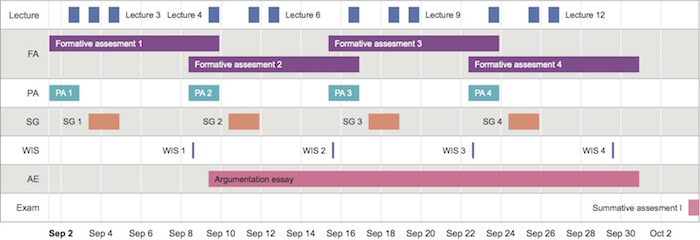

Course outline

## Course outline

- Lectures
- SG: Mandatory study groups
- FA: Digital formative assessment
- PA: Preparatory assignments
- WIS: Walk-in sessions
- AE: Argumentation essay
- Exam: Mid term exam

\[\text{Final grade} = .8 \times \overline{Exam} + .2 \times \overline{AE} - SG - FA - PA\]

## Deduction points

| Not met | SG | PA | FA |
| --- | --- | --- | --- |
| 1x | 0 | 0 | 0 |
| 2x | 0.25 | 0.1 | 0.1 |
| 3x | 0.75 | 0.25 | 0.25 |
| 4x | 1.5 | 0.5 | 0.5 |
| 5x | 3 | 1 | 1 |
| 6x | Exclusion | Exclusion | Exclusion |

## Digital formative assessment

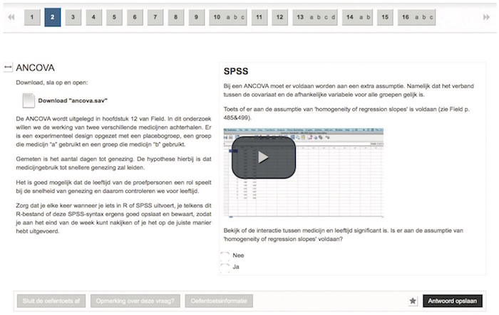

Formative assessment example

## Digital formative assessment

- [Remindo](https://uva.remindotoets.nl)
- [Testvision](https://uva.testvision.nl/online/fe/login_tvb.htm)

## Digital formative assessment

- 14 Formative assessments
- No points are given
- Only deduction for not making the assignments

## Lecture Attendance

- Not compulsory
- Registered in the first and final cycle of the course

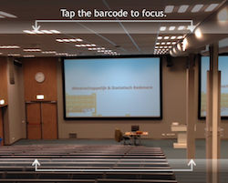

QR scanner

## Weblectures

Apart from the above described course design, students also have access to the [weblectures](http://webcolleges.uva.nl/Mediasite/Play/bb82160b73f14bed9648b879f8dc4e5e1d?playFrom=4575000) from our campus video lecture capture system. These weblectures are available directly after the lecture has been given.

## Exam

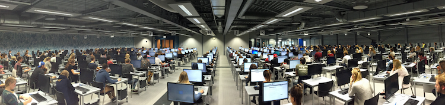

Exam hall

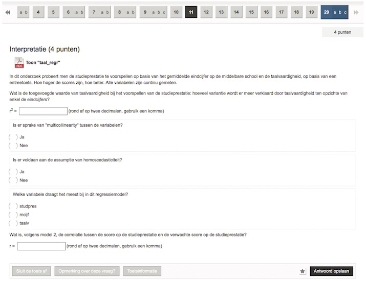

## Evaluating course design

## The role of formative assessment in a blended learning course

[Klinkenberg, S. (2017). The role of formative assessment in a blended learning course. In D. Joosten-ten Brinke, & M. Laanpere (Eds.), Technology enhanced assessment: 19th international conference, TEA 2016, tallinn, estonia, october 5-6, 2016, revised selected papers (pp. 63-71). Cham: Springer International Publishing.](https://link.springer.com/chapter/10.1007/978-3-319-57744-9_6)

## Lecture attendance and formative assessment

Lecture attendance and formative assessment explained 29% \(F(2, 271) = 55.2, p < 0.001\) of the variance.

- Lecture attendance \(b = −0.006\) \(t(271) = −0.31, p > .05\)
- Formative assessment \(b = 0.22\) \(t(271) = 10.49, p < .001\)

## Weblectures

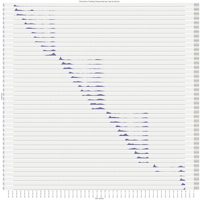

weblectures

## Personalised Learning

## Diagnostics

Use categorised results of assesment to diagnose problems.

[figure not shown]

Diagnostics

## Remediation

Create remediation sessions for "personalised" intervention.

## END

- [@shklinkenberg](https://twitter.com/shklinkenberg)
- [Klinkenberg](https://www.linkedin.com/in/sharonklinkenberg/)
- ln.AvU@grebneknilK.S